# Text Analysis: Matching and Linking

Northwestern IT Research Computing Services

November 21, 2019

### 1: Getting Started

Welcome to the Text Analysis: Matching and Linking Workshop! Today, we will discuss the use of fuzzy linkage techniques to merge data sets at the research scale (small to medium size data sets). If you have any specific questions following the workshop, please feel free to email me (*austinalleman2020@u.northwestern.edu*) or [request a consultation with RCS](https://www.it.northwestern.edu/service-catalog/research/data-services/data-science.html).

##### 1.1: Installing and Loading Packages

The packages we depend on in this session are checked for and, if necessary, installed below.

```r
# Check if tidyverse is installed. If not, install it. This package standardizes a wide variety of data manipulation and modeling packages.
if(!require(tidyverse)){
    install.packages("tidyverse")
}

# Check if stringdist is installed. If not, install it. This package implements string distance/similarity metrics.
if(!require(stringdist)){
    install.packages("stringdist")
}

# Check if fuzzyjoin is installed. If not, install it. This package implements joins based on string distances.
if(!require(fuzzyjoin)){
    install.packages("fuzzyjoin")
}

# Load libraries.
library(tidyverse)
library(stringdist)
library(fuzzyjoin)
```

##### 1.2: Preliminaries

In this workshop, we will lean on `tidyverse` data manipulation techniques. The functions you should be familiar with, and some examples on a toy data set:

```r
# Creating toy data set
df <- tibble(x = c(1,2,3,4,5,6),
             y = c("R", "C", "S", "R", "C", "S"))
df
```

```
## # A tibble: 6 x 2
##       x y
##   <dbl> <chr>
## 1     1 R
## 2     2 C
## 3     3 S
## 4     4 R
## 5     5 C
## 6     6 S
```

`select(df, vars)`: selects variables by name or using helper functions from `df`

```r
select(df, x)
```

```
## # A tibble: 6 x 1
##       x
##   <dbl>
## 1     1
## 2     2
## 3     3
## 4     4
## 5     5
## 6     6
```

```r
select(df, x, y)
```

```
## # A tibble: 6 x 2
##       x y
##   <dbl> <chr>
## 1     1 R
## 2     2 C
## 3     3 S
## 4     4 R
## 5     5 C
## 6     6 S
```

```r
select(df, -x)
```

```
## # A tibble: 6 x 1
##   y
##   <chr>
## 1 R
## 2 C
## 3 S
## 4 R
## 5 C
## 6 S
```

`filter(df, cond)`: returns rows from `df` where `cond` is `TRUE`

```r
filter(df, y == "R")
```

```
## # A tibble: 2 x 2
##       x y
##   <dbl> <chr>
## 1     1 R
## 2     4 R
```

```r
filter(df, x > 2,
       y == "S")
```

```
## # A tibble: 2 x 2
##       x y
##   <dbl> <chr>
## 1     3 S
## 2     6 S
```

`arrange(df, vars)`: arranges rows from `df` by ascending values of `vars`, in order (can use `desc(var)`)

```r
arrange(df, y, x)
```

```
## # A tibble: 6 x 2
##       x y
##   <dbl> <chr>
## 1     2 C
## 2     5 C
## 3     1 R
## 4     4 R
## 5     3 S
## 6     6 S
```

```r
arrange(df, desc(x))
```

```
## # A tibble: 6 x 2
##       x y
##   <dbl> <chr>
## 1     6 S
## 2     5 C
## 3     4 R
## 4     3 S
## 5     2 C
## 6     1 R
```

`mutate(df, expr)`: creates new variables from the contents of `df` according to `expr`

```r
mutate(df, a = 2*x,
       b = paste0(y, "!"))
```

```
## # A tibble: 6 x 4
##       x y         a b
##   <dbl> <chr> <dbl> <chr>
## 1     1 R         2 R!
## 2     2 C         4 C!
## 3     3 S         6 S!
## 4     4 R         8 R!
## 5     5 C        10 C!
## 6     6 S        12 S!
```

`group_by(df, vars)`: specifies that operations should be done within groups defined by combinations of values of `vars`

```r
group_by(df, y)
```

```
## # A tibble: 6 x 2
## # Groups:   y [3]
##       x y
##   <dbl> <chr>
## 1     1 R
## 2     2 C
## 3     3 S
## 4     4 R
## 5     5 C
## 6     6 S
```

`summarize(df, fcns)`: produces aggregates `fcns`, and when used in conjunction with `group_by`, aggregates within groups.

```r
summarize(df, x_sum = sum(x))
```

```
## # A tibble: 1 x 1
##   x_sum
##   <dbl>
## 1    21
```

`View(df)`: opens `df` in the data browser for easy viewing

```r
View(df)
```

`%>%`: supplies the result on its left as the implicit first argument to an operation on its right

```r
df %>% View()   # same as View(df)

df %>%
  group_by(y) %>%
  summarize(x_sum = sum(x))
```

##### 1.2.1: Exercise

```r
df %>%
  mutate(z = 4*x) %>%            # "create column" means "mutate"
  select(y, z) %>%               # "retrieve columns" means "select"
  filter(z > 8) %>%              # "retrieve rows where..."
  group_by(y) %>%                # do operations within values of a variable means "group_by"
  summarize(n_times = n(),       # aggregate operation means "summarize"
            z_sum = sum(z)) %>%
  arrange(desc(z_sum))           # "arrange by descending var" means...arrange by desc(var)
```

```
## # A tibble: 3 x 3
##   y     n_times z_sum
##   <chr>   <int> <dbl>
## 1 S           2    36
## 2 C           1    20
## 3 R           1    16
```

##### 1.3: Loading Data

We will use the following data sets as part of the workshop. The first is the [2018 US News & World Report’s Top 20(ish) Computer Science programs](https://www.usnews.com/best-graduate-schools/top-science-schools/computer-science-rankings), constructed manually below:

```r
top_20_cs_schools <- c("Carnegie Mellon University",
                       "Massachusetts Institute of Technology",
                       "Stanford University",
                       "University of California, Berkeley",
                       "University of Illinois, Urbana-Champaign",
                       "Cornell University",
                       "University of Washington",
                       "Georgia Institute of Technology",
                       "Princeton University",
                       "University of Texas, Austin") #,
                       #"California Institute of Technology",
                       #"University of Michigan, Ann Arbor",
                       #"Columbia University",
                       #"University of California, Los Angeles",
                       #"University of Wisconsin, Madison",
                       #"Harvard University",
                       #"University of California, San Diego",
                       #"University of Maryland, College Park",
                       #"University of Pennsylvania",
                       #"Rice University")

unswr_rank = 1:10 #1:20
csr_rank = c(1,2,4,5,3,7,6,11,20,17) #,65,8,12,16,13,24,9,10,14,48)
nrc_rank = c(4,2,1,5,6,7,24,12,3,14) #,63,17,20,10,18,9,16,15,13,47)

institution_tbl <- tibble(institution = factor(top_20_cs_schools,
                                               levels = top_20_cs_schools),
                          unswr_rank = unswr_rank,
                          csr_rank = csr_rank,
                          nrc_rank = nrc_rank)

institution_tbl
```

```
## # A tibble: 10 x 4
##    institution                              unswr_rank csr_rank nrc_rank
##    <fct>                                         <int>    <dbl>    <dbl>
##  1 Carnegie Mellon University                        1        1        4
##  2 Massachusetts Institute of Technology             2        2        2
##  3 Stanford University                               3        4        1
##  4 University of California, Berkeley                4        5        5
##  5 University of Illinois, Urbana-Champaign          5        3        6
##  6 Cornell University                                6        7        7
##  7 University of Washington                          7        6       24
##  8 Georgia Institute of Technology                   8       11       12
##  9 Princeton University                              9       20        3
## 10 University of Texas, Austin                      10       17       14
```

The second is a webscraped data set of manual entry graduate admissions results for students applying to ‘Computer Science’ programs from [The Grad Cafe](https://www.thegradcafe.com/survey/index.php), where users can submit their own data, including GPA, GRE scores, admission result and date, and comments. The challenge with this data is that *everything* is manual entry – including the name of the school.

```r
admissions_results <- read_csv("data/gradcafe_cs_results.csv")
```

Let’s take a quick look at this data set. There are roughly 42,000 admissions results:

```r
admissions_results %>%
  summary()
```

```
##  institution         date_added          decision
##  Length:42613       Length:42613       Length:42613
##  Class :character   Class :character   Class :character
##  Mode  :character   Mode  :character   Mode  :character
##
##
##
##
##  decision_date        decision_day         program
##  Min.   :0201-02-13   Length:42613       Length:42613
##  1st Qu.:2012-03-23   Class :character   Class :character
##  Median :2015-04-17   Mode  :character   Mode  :character
##  Mean   :2014-11-10
##  3rd Qu.:2018-02-09
##  Max.   :2019-12-15
##  NA's   :2
##     degree               gpa          gre_verbal      gre_quant
##  Length:42613       Min.   :0.900   Min.   :  0.0   Min.   :  0.0
##  Class :character   1st Qu.:3.500   1st Qu.:154.0   1st Qu.:163.0
##  Mode  :character   Median :3.700   Median :159.0   Median :167.0
##                     Mean   :3.812   Mean   :211.9   Mean   :240.9
##                     3rd Qu.:3.880   3rd Qu.:165.0   3rd Qu.:170.0
##                     Max.   :9.990   Max.   :801.0   Max.   :900.0
##                     NA's   :30821   NA's   :28553   NA's   :28553
##     gre_awa
##  Min.   : 0.000
##  1st Qu.: 3.500
##  Median : 4.000
##  Mean   : 4.202
##  3rd Qu.: 4.500
##  Max.   :99.990
##  NA's   :28553
```

##### 1.3.1: Exercise

Show the top schools by number of reported results. Display the top 50 results (`?print`).

```r
admissions_results %>%
  group_by(institution) %>%
  summarize(num_results = n()) %>%
  arrange(desc(num_results)) %>%
  print(n = 50)
```

```
## # A tibble: 3,028 x 2
##    institution                                     num_results
##    <chr>                                                 <int>
##  1 Stanford University                                    1046
##  2 Columbia University                                     873
##  3 Carnegie Mellon University                              782
##  4 Carnegie Mellon University (CMU)                        717
##  5 University Of Toronto                                   688
##  6 Cornell University                                      638
##  7 University Of Southern California (USC)                 613
##  8 University Of Washington                                542
##  9 Massachusetts Institute Of Technology (MIT)             490
## 10 Princeton University                                    478
## 11 University Of Southern California                       415
## 12 Brown University                                        398
```

[output cut: 39 more lines]

##### 1.4: Joining Data

As enterprising graduate students, we’re only interested in the admission results corresponding to USNWR’s top 10 programs. Using our first table, we can perform an inner join on the the second table to get results corresponding only to those programs:

```r
join_results <- institution_tbl %>%
  inner_join(admissions_results,
             by = c("institution" = "institution"))
join_results %>%
  group_by(institution) %>%
  summarize(num_results = n(),
            unswr_rank = max(unswr_rank)) %>%
  arrange(unswr_rank)
```

```
## # A tibble: 7 x 3
##   institution                              num_results unswr_rank
##   <chr>                                          <int>      <int>
## 1 Carnegie Mellon University                       782          1
## 2 Massachusetts Institute of Technology            147          2
## 3 Stanford University                             1046          3
## 4 University of California, Berkeley                 6          4
## 5 University of Illinois, Urbana-Champaign         171          5
## 6 Cornell University                               638          6
## 7 Princeton University                             478          9
```

A naive join yields only 7 out of 10 programs with a match, and many with unbelievably few results . The other 3 programs don’t have matches because the join key, `institution`, doesn’t match anything in our manual entry data set. We can alleviate this problem to some extent by removing capitalizations, punctuations, and “stop words” in the join key that may result in mismatches:

```r
institution_tbl_adj <- institution_tbl %>%
  mutate(institution_key = str_trim(str_replace_all(str_to_lower(institution), "[:punct:]|university|institute|\\sof\\s|\\sand\\s|\\sat\\s", "")))

admissions_results_adj <- admissions_results %>%
  mutate(institution_key = str_trim(str_replace_all(str_to_lower(institution), "[:punct:]|university|institute|\\sof\\s|\\sand\\s|\\sat\\s", "")))
```

Now we try our join again:

```r
join_results_adj <- institution_tbl_adj %>%
  inner_join(admissions_results_adj,
             by = c("institution_key" = "institution_key"))

join_results_adj %>%
  group_by(institution.x) %>%
  summarize(num_results = n(),
            unswr_rank = max(unswr_rank)) %>%
  arrange(unswr_rank)
```

```
## # A tibble: 10 x 3
##    institution.x                            num_results unswr_rank
##    <fct>                                          <int>      <int>
##  1 Carnegie Mellon University                       851          1
##  2 Massachusetts Institute of Technology            166          2
##  3 Stanford University                             1389          3
##  4 University of California, Berkeley               262          4
##  5 University of Illinois, Urbana-Champaign         211          5
##  6 Cornell University                               811          6
##  7 University of Washington                         553          7
##  8 Georgia Institute of Technology                  319          8
##  9 Princeton University                             605          9
## 10 University of Texas, Austin                       75         10
```

Standardizing our join key has ensured that we find matches for every one of our top 10 programs in `institution_tbl`. But alas, just among the schools with the most results, we noticed several inconsistencies – added abbreviations, some schools missing “University” in the name. Let’s go further down the list:

```r
admissions_results_adj %>%
  group_by(institution_key) %>%
  summarize(num_results = n()) %>%
  arrange(desc(num_results)) %>%
  print(n = 50)
```

```
## # A tibble: 2,346 x 2
##    institution_key                num_results
##    <chr>                                <int>
##  1 stanford                              1389
##  2 columbia                               929
##  3 carnegie mellon                        851
##  4 cornell                                811
##  5 carnegie mellon  cmu                   725
##  6 toronto                                697
##  7 southern california usc                616
##  8 princeton                              605
##  9 washington                             553
## 10 southern california                    533
## 11 massachusetts technology mit           492
## 12 brown                                  451
```

[output cut: 39 more lines]

We could keep applying applying new rules, e.g., remove anything in parentheses, but in general this strategy is doomed to fail as many rows will contain misspelled university names (“University of California, Berkley”), reordered components of the university names (“University of Stanford”), or department names (“Cornell Tech”). Luckily, there’s an alternative strategy available – we *could* use a fuzzy matching scheme to match where names are almost the same.

### 2: Fuzzy Matching via String Distances

The most common variant of fuzzy matching is based on the concept of string similarity or distance. If we could decide how close together two strings are in some meaningful way, we could establish a matching threshold. It’s something of an art, as its efficacy depends in descending order on:

- how you decide on a string distance and match threshold
- how comfortable you are with estimated false matching rates
- whether one of your data sets has a “clean” key to match with

##### 2.1: String Distances

The first point brings us to the core principle of fuzzy matching – string distances. A string distance is a function that accepts two strings as input, and returns a number measuring the degree of difference between the two strings. For example, if we have the strings “Northwestern”, “Northeastern”, and “Vanderbilt”, we expect that a string distance function tells us that the first two strings are not very different, while any other pair should be identified as very different.

We’ll talk about two specific examples during this workshop – the Levenshtein distance, and Jaccard similarity – although there are many others.

##### 2.1.1: Levenshtein Distance

```r
stringdist("Northwestern", "Northwestern",
           method = "lv")
```

```
## [1] 0
```

```r
stringdist("Northwestern", c("Northwestern", "Northeastern", "Vanderbilt"),
           method = "lv")
```

```
## [1]  0  2 11
```

##### 2.1.2: Jaccard Similarity

```r
# qgram distance, q = 2
stringdist("Northwestern", c("Northwestern", "Northeastern", "Vanderbilt"),
           method = "qgram", q = 2)
```

```
## [1]  0  6 18
```

```r
# jaccard similarity
stringdist("Northwestern", c("Northwestern", "Northeastern", "Vanderbilt"),
           method = "jaccard", q = 2)
```

```
## [1] 0.0000000 0.4285714 0.9473684
```

##### 2.1.3: Exercise

Turn to your neighbors and compare your names using string distances. You can use the examples above, but you should feel free to take a look at the documentation (`?stringdist` and `?stringdist-metrics`) to see which methods and control parameters are available to you.

### 2.2: Applying String Distances to Joins

```r
fuzzy_join_results <- institution_tbl_adj %>%
  stringdist_inner_join(admissions_results_adj,
             by = c("institution_key" = "institution_key"),
             method = "jaccard", q = 2, max_dist = .4,
             distance_col = "dist")

fuzzy_join_results %>%
  group_by(institution.x) %>%
  summarize(num_results = n(),
            unswr_rank = max(unswr_rank)) %>%
  arrange(unswr_rank)
```

```
## # A tibble: 10 x 3
##    institution.x                            num_results unswr_rank
##    <fct>                                          <int>      <int>
##  1 Carnegie Mellon University                      1908          1
##  2 Massachusetts Institute of Technology            811          2
##  3 Stanford University                             1396          3
##  4 University of California, Berkeley               705          4
##  5 University of Illinois, Urbana-Champaign        1151          5
##  6 Cornell University                               814          6
##  7 University of Washington                         627          7
##  8 Georgia Institute of Technology                 1147          8
##  9 Princeton University                             607          9
## 10 University of Texas, Austin                      826         10
```

```r
fuzzy_join_results %>%
  group_by(institution.x, institution.y) %>%
  summarize(num_results = n(),
            dist = max(dist)) %>%
  arrange(desc(dist)) %>%
  print(n = 100)
```

```
## # A tibble: 248 x 4
## # Groups:   institution.x [10]
##     institution.x          institution.y                  num_results  dist
##     <fct>                  <chr>                                <int> <dbl>
##   1 Carnegie Mellon Unive… Carnagie Mellon University(CM…           9 0.4
##   2 Carnegie Mellon Unive… Carnege Mellon University - L…          22 0.4
##   3 Carnegie Mellon Unive… Carnege Mellon University (CM…          27 0.4
##   4 University of Washing… George Washington University            27 0.4
##   5 University of Washing… University Of Washington - HC…           1 0.4
##   6 University of Washing… Washington State University             20 0.4
##   7 University of Texas, … University Of Texas At Austin…           1 0.4
##   8 Georgia Institute of … Georgia Insititute Of Technol…          21 0.393
##   9 Carnegie Mellon Unive… Carnegie Mellon University (C…          10 0.391
##  10 Carnegie Mellon Unive… Carnegie Mellon University (C…           1 0.391
##  11 Carnegie Mellon Unive… Carnegie Mellon University (S…           6 0.391
```

[output cut: 90 more lines]

Now, we can actually reap the fruits of our labor:

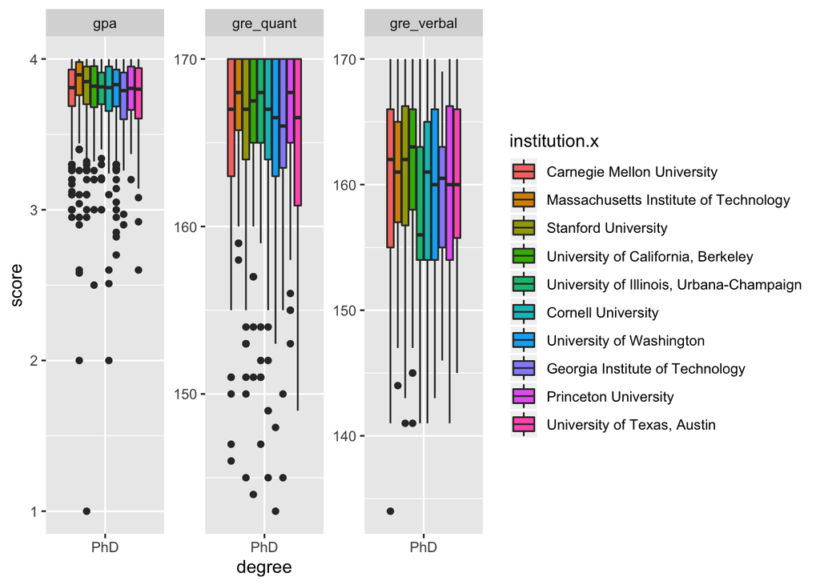

```r
fuzzy_join_results %>%
  mutate(gpa = ifelse(gpa <= 0 | gpa > 4, NA, gpa),
         gre_quant = ifelse(gre_quant < 130 | gre_quant > 170, NA, gre_quant),
         gre_verbal = ifelse(gre_verbal < 130 | gre_verbal > 170, NA, gre_verbal)) %>%
  filter(!is.na(gpa), degree %in% c("PhD")) %>%
  select(institution.x,
         degree,
         gpa,
         gre_quant,
         gre_verbal) %>%
  gather(key = "metric", value="score", -institution.x, -degree) %>%
  ggplot() +
    geom_boxplot(aes(x = degree, y = score, fill = institution.x)) +
    facet_wrap(~ metric, scales = "free")
```

```r
  #group_by(institution.x) %>%
  #summarize(num_results = n(),
  #          median_gpa = median(gpa, na.rm = TRUE),
  #          median_gre_v = median(gre_verbal, na.rm = TRUE),
  #          median_gre_q = median(gre_quant, na.rm = TRUE),
  #          unswr_rank = max(unswr_rank),
  #          pct_below_min_gpa = sum(gpa < sugg_min_gpa_reqs, na.rm = TRUE)/n()) %>%
```

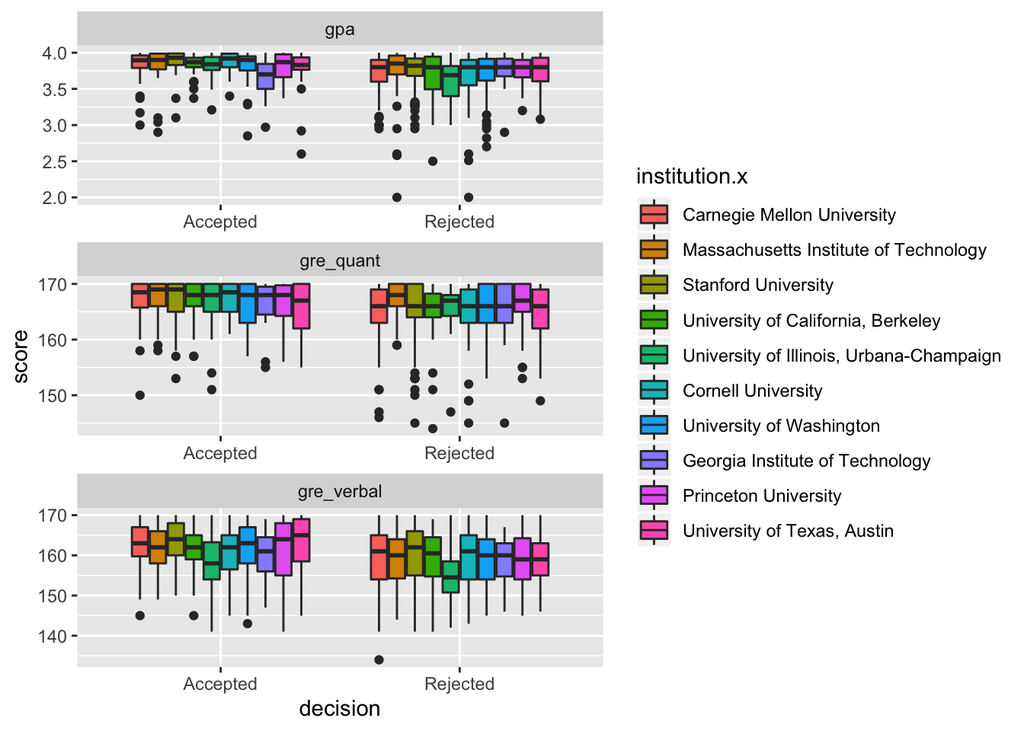

```r
fuzzy_join_results %>%
  mutate(gpa = ifelse(gpa < 2 | gpa > 4, NA, gpa),
         gre_quant = ifelse(gre_quant < 130 | gre_quant > 170, NA, gre_quant),
         gre_verbal = ifelse(gre_verbal < 130 | gre_verbal > 170, NA, gre_verbal)) %>%
  filter(!is.na(gpa), degree == "PhD", decision %in% c("Accepted","Rejected")) %>%
  select(institution.x,
         decision,
         gpa,
         gre_quant,
         gre_verbal) %>%
  gather(key = "metric", value="score", -institution.x, -decision) %>%
  ggplot() +
    geom_boxplot(aes(x = decision, y = score, fill = institution.x)) +
    facet_wrap(~ metric, scales = "free", ncol = 1)
```

```r
  #group_by(institution.x) %>%
  #summarize(num_results = n(),
  #          median_gpa = median(gpa, na.rm = TRUE),
  #          median_gre_v = median(gre_verbal, na.rm = TRUE),
  #          median_gre_q = median(gre_quant, na.rm = TRUE),
  #          unswr_rank = max(unswr_rank),
  #          pct_below_min_gpa = sum(gpa < sugg_min_gpa_reqs, na.rm = TRUE)/n()) %>%
```